# Getting started with Rmarkdown presentations

Brad Duthie

18 FEB 2025

# Before starting to code

# When and how to start making Rmarkdown slides

- Start for an informal presentation
  - Will not need to do anything fancy
  - Minor errors not a big deal
  - Can get started quickly
- Build confidence and learn new style tricks over time
  - Add [cascading style sheets (CSS)](https://github.com/StirlingCodingClub/css) for HTML
  - Integrate LaTeX for PDF slides
- Avoid anxiety of having presentation limited by technical skill
- More
- More
- And more text
- Avoid anxiety of having presentation limited by technical skill
- Avoid anxiety of having presentation limited by technical skill
- Avoid anxiety of having presentation limited by technical skill

# Four types of outputs using knit

New Line!

1. HTML (ioslides): Not very elegant, but can use columns and shiny easily
2. HTML (slidy): Nicer looking, but columns are tricky and not for shiny
3. PDF (LaTeX): Nice looking, but no shiny and might need to know LaTeX
4. PPTX (Powerpoint): Probably looks okay for some things, but never works for me in LibreOffice

**Need to install [rmarkdown](https://cran.r-project.org/web/packages/rmarkdown/index.html) and [knitr](https://cran.r-project.org/web/packages/knitr/index.html) packages**

# The long-term goal is to do what you cannot (easily) in PowerPoint

- Quickly and easily produce a consistent slide layout
- Integrate R analysis and plots **directly** into a presentation
- Make interactive slides using [Rshiny](https://shiny.rstudio.com/)
- Use [version control](https://stirlingcodingclub.github.io/version_control/vc_notes.html) when writing and maintaining slides
- Ultimately produce slides more quickly through text and reuse of old code

# Plot random normal values

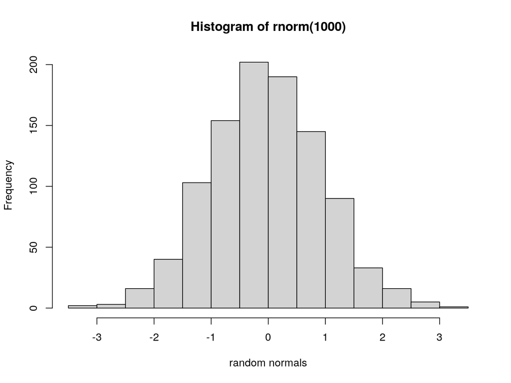

# Some tricks to get started with the code

# Select a new Rmarkdown presentation

- The output format is completely unimportant
- You can get rid of everything but the first lines

```
---
title: "Untitled"
author: "Brad Duthie"
date: "28/02/2024"
output: ioslides_presentation
---
```

- The YAML specifies some meta-data
  - ‘Yet Another Markup Language’
  - Can add to it (e.g., reference styles, format options, etc.)
  - Everything below the YAML is meant to introduce you to Rmarkdown slides

# Getting started is really easy

The syntax can be used for any type of slide (HTML, PDF, PPTX)

```
# This makes a title slide

## This is a normal slide

- Bullet 1 on normal slide
- Bullet 2 on normal slide

## Links are easy

- Link to [UoS website](https://www.stir.ac.uk/)
```

Simple text slides are especially easy to write quickly

# Adding images to an Rmarkdown slide

Images can be added with a single line of code:

```
![Optional figure legend](logo.png){width=20%}
```

Could have also used the below

```r
include_graphics("logo.png",
                 fig.cap = "Optional figure legend");
```

# Running code in an Rmarkdown slide

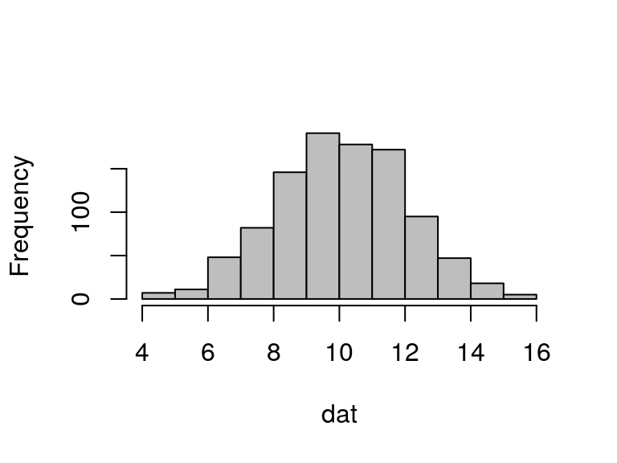

```r
# The code below is actually being run
dat <- rnorm(n = 1000, mean = 10, sd = 2);

# We can plot a histogram of it below
hist(dat, main = "",col = "grey");
```

# Separating a slide into columns gets tricky

Dividing an entire slide into two columns can be done using a bit of code at the end of the title.

```
## Slide title {.columns-2}
```

This applies to the whole slide though, even if you only want columns for a portion of the slide.

It also only works for ioslides presentations.

# Separating a slide into columns gets tricky

- Work-arounds to force breaks between columns and make everything look better
- Figuring out the columns even just for ioslides is not much fun
- At this point you might need to settle on an output type (ioslides, slidy, PDF)

# Separating a slide into columns gets tricky

Using LaTeX can be powerful inside Rmarkdown, but takes time to learn, and only works for PDFs.

```
\begin{columns}

\begin{column}{0.5\textwidth}
'''{r, out.width = "100%", echo = FALSE}
library("knitr")
include_graphics("logo.png");
'''
\end{column}

\begin{column}{0.5\textwidth}
\begin{itemize}
\setlength\itemsep{1.0em}
\item Using LaTeX can make things look nice
\item Only possible for PDFs
\item Need to know yet more code
\end{itemize}
\end{column}
\end{columns}
```

# Separating a slide into columns gets tricky

# Maths can be expressed especially well in PDF

```
$$e^{i\pi} + 1 = 0$$
```

$$e^{i\pi} + 1 = 0$$

```
$$P(x) = \frac{1}{\sigma\sqrt{2\pi}}e^{-\frac{1}{2}
         \left(\frac{x - \mu}{\sigma} \right)^{2}}$$
```

$$P(x) =
\frac{1}{\sigma\sqrt{2\pi}}e^{-\frac{1}{2} \left(\frac{x - \mu}{\sigma}
\right)^{2}}$$

# Maths can be expressed especially well in PDF

```
$$E[X] = \int_{x}xf(x)dx$$
```

$$E[X] = \int_{x}xf(x)dx$$

[Equation editors](https://www.codecogs.com/latex/eqneditor.php) can convert to LaTeX

# You will probably have to make compromises

If all else fails, you can just make a picture of what you want and insert it as an image

# This is a new slide

- Bullet point 1
- Bullet point 2